# Trading effects

Ernesto Carrella

August 24, 2015

I enabled a simple form of ITQ trading and use it to study simple policy results.  
Faster fishing means more catches both with TACs and ITQs. Being more efficient at fishing is rewarded only in ITQs.

## Baseline results

I give all fishers the same boat and the same gear. I do this to isolate TAC and ITQ effects on the distribution of catches.  
Even though all boats are the same there is noise in their profitability due to exploration randomness and luck with social networks.

#### TACs

In the TAC example there are 100 fishers. There is a total allowed catch of 400,000 units of a fish. The sixth year distribution of catches is somewhat dispersed around the 4000 units per boat mark:

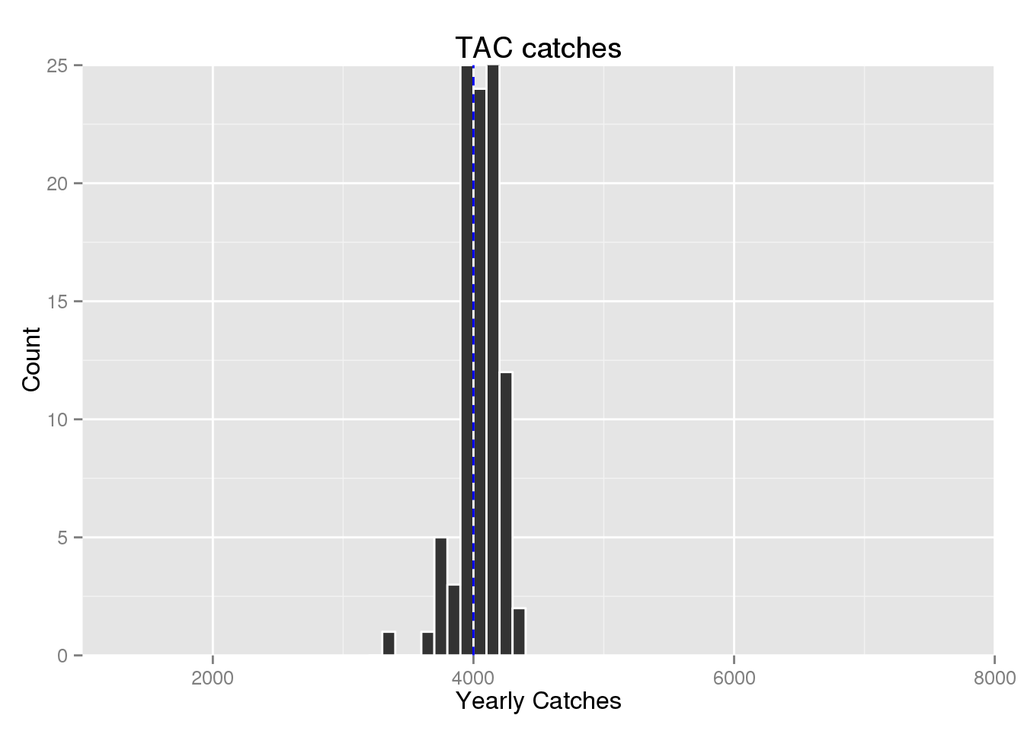

#### ITQs

A similar spread of catches occur if we keep everything constant but place an ITQ rather than TAC policy in place. Every fisher is given 4000 quotas a year (these are reset at the end of every year). Fishers that are unlucky with their exploration slowly sell their quotas to the luckier ones

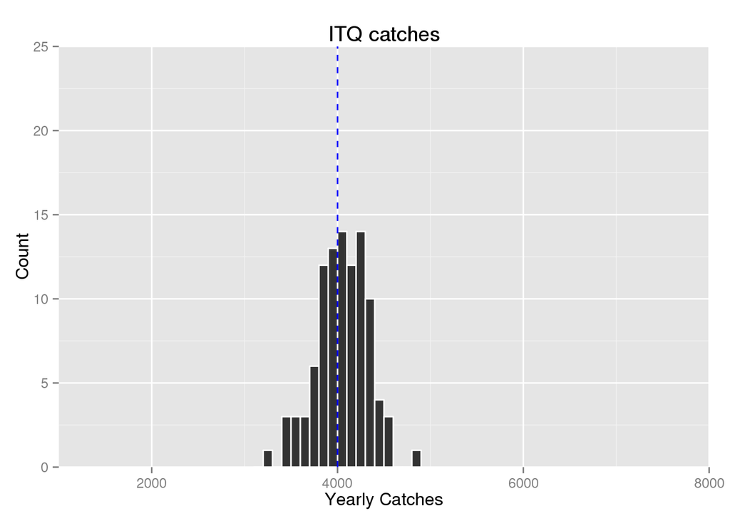

Again a bell-shaped catches distribution albeit a flatter and wider one compared to TAC. Now that we know how the background noise of the simulation distributes yearly quotas we can better appreciate policy effects when boats are not homogeneous.

## Better Gear

#### TACs

Starting with TAC, notice first that the shape of catches distribution is fundamentally different:

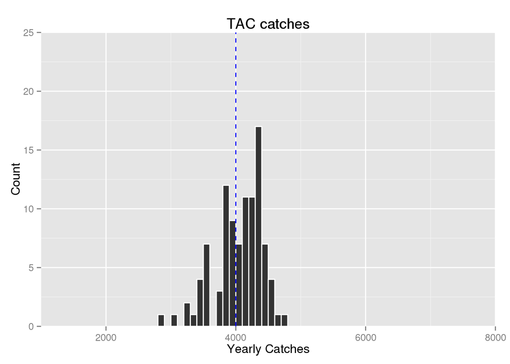

This is due to the fact that boats with better gear, and so better catchability, are able to fish more:

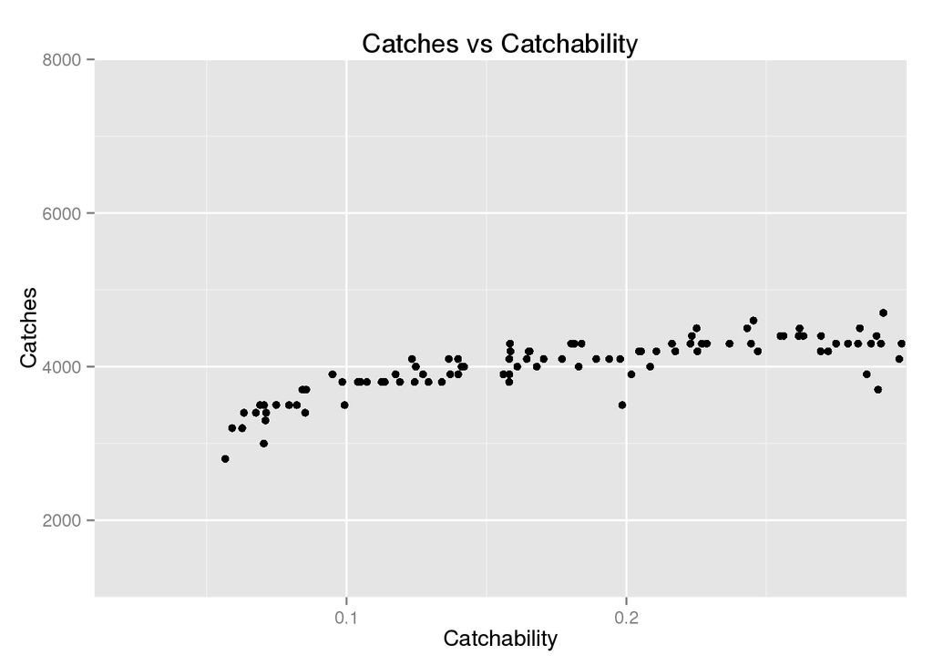

The correlation between catchability and catches is 0.81.

This is somewhat of an obvious result: in a TAC environment fishers are racing to fulfill as much of the quota as possible before it is all taken. More catches per hour is an advantage as it allows for more trips before the fishery closes.

#### ITQs

ITQ policy also incentivates fishers with better gear to fish more. The distribution of catches becomes flatter and wider:

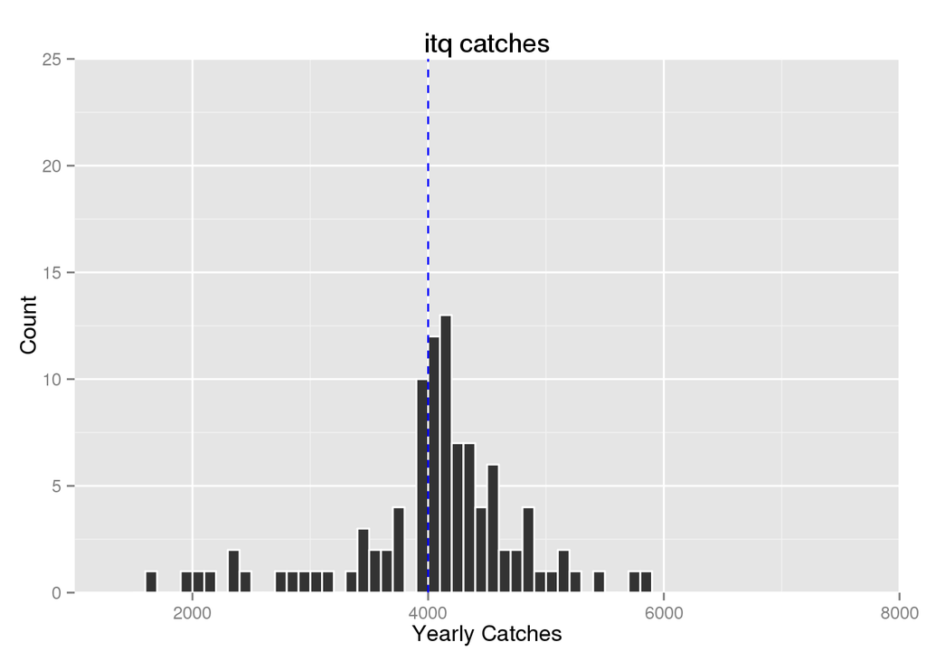

And again fishers with better gear make more catches (correlation of: 0.77):

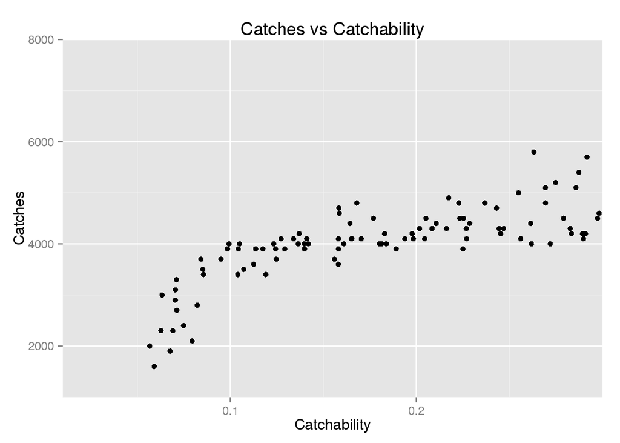

For both ITQs and TACs there is a correlation between having better gear and catching more fish even though the mechanism is different. In TACs the race to fish rewards faster fishers, in ITQs faster fishers make more profits per trip (as they consume less time and gas fishing) and therefore value quotas more.  
Notice how for the parameters chosen, ITQs tend to reward better gear more: having a catchability .1 higher means 412 more catches a year with TAC, but it means 806 more with an ITQ.

## Better mileage

Now the fishers are again homogeneous in catchability. Their only difference is the amount of gas consumed per hour spent fishing, which used to be fixed at $5$ for all boats in the previous section and is instead here uniformly distributed $\sim U[0,20]$.  
While energy efficiency is profitable, in TACs it doesn’t translate in more catches. In ITQs instead having better mileage is heavily rewarded.

#### TACs

The catches distribution with TACs returns to its original bell-shape:

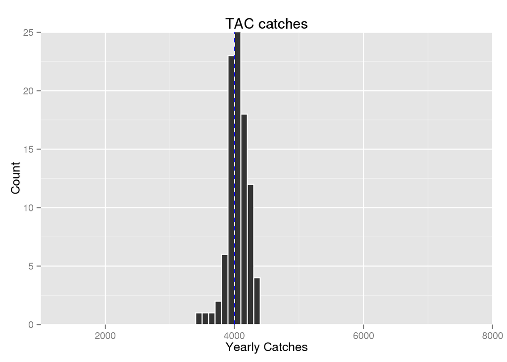

And gas efficiency has no impact on yearly catches (correlation of: -0.007)

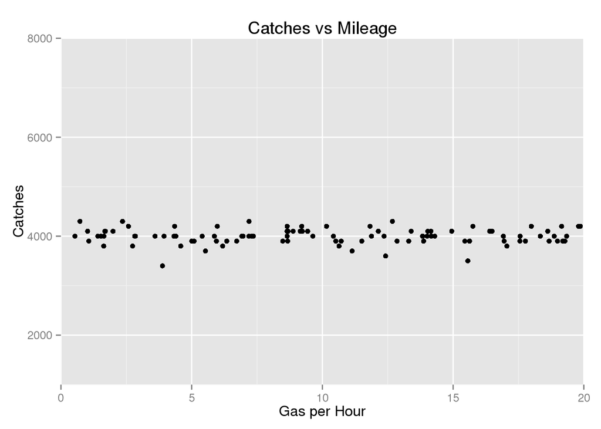

The race to fish dynamic does not reward fuel efficiency.

#### ITQs

Very different are the results with ITQs. Difference in fuel efficiency (with expensive gas) results in a very unequal distribution of catches:

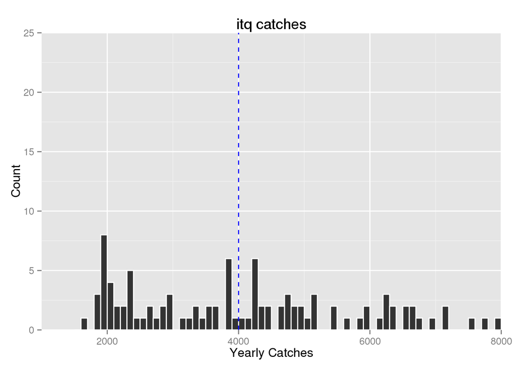

And with ITQs it’s very clear that more wasteful boats will catch a lot less (correlation of: -0.934):

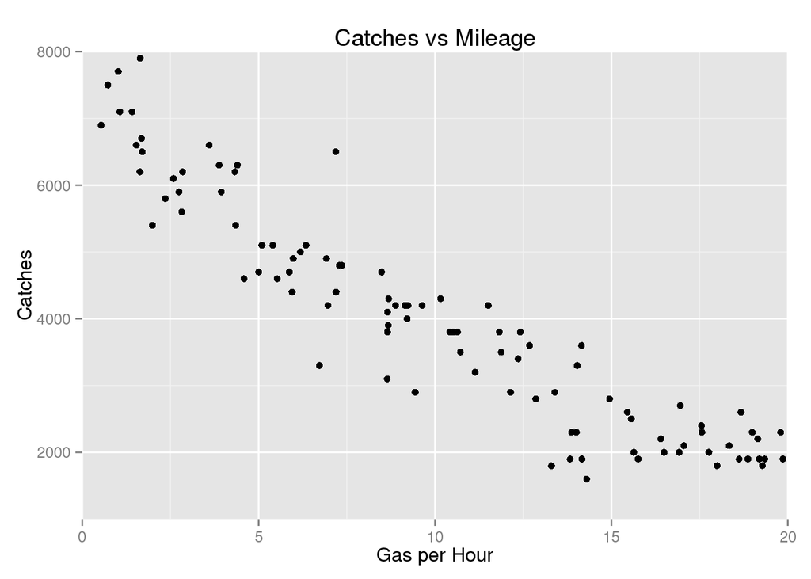

ITQs then reward efficiency even when it is not narrowly related to catches per unit of effort, unlike TACs.

Again these results are somewhat cartoony as they depend on parameters that are unrealistic both biologically and technologically but this allows me to make the results starker while keeping the moving parts of the model to a minimum.